# Prezentacja PSE

Analiza i prognozowanie szeregów czasowych  
na przykładzie rzeczywistych danych z punktu gastronomicznego

## **Cel prezentacji:**

- przedstawienie procesów podejmowania decyzji w trakcie analizy danych
- użycie rzeczywistych danych
  - celem odwzorowania realnych problemów występujacych przy analizie
  - dalszego rozowoju modelu w celach badawczo-rozwojowych przedsiebiostwa
- podobny zbiór metod do analizy danych i prognoz mogących być używanymi w PSE (https://ekordo.pl/prognoza-zuzycia-energii-elektrycznej/)
- odmienna dziedzina zastosowania metod
- względnie prosty i mały zestaw danych umożliwiających ich edycję i przetwarzanie w czasie rzeczywistym w prezentacji

## **Wykorzystane model analityczne:**

1. Naiwne - porównwcze
2. Złożona średnia ruchoma - metoda referencyjna
3. SARIMA i SARIMAX
4. ML Random Forest

**Wykorzystane narzędzia w projekcie:**

1. IDE oraz prezentacji**:** jupyter notebook, nbextensions, RISE
2. Podstawowa manipulacja danymi: sys, os, pandas, numpy
3. EDA : ydata_profiling
4. Modele SARIMA i SARMIAX: statsmodels, pmdarima
5. Model ML i metryki błędu: sklearn
6. Narzędzia graficzne: seaborn, matplotlib

```python
import warnings
warnings.filterwarnings('ignore')
```

```python
#Wczytanie pakietów do IDE
import os
import pandas as pd
import numpy as np
import pmdarima as pm
import sklearn
import seaborn as sns
import matplotlib.pyplot as plt
import statsmodels
import datetime




from statsmodels.tsa.stattools import adfuller
import statsmodels.api as sm
from ydata_profiling import ProfileReport
from datetime import datetime
```

### **Wstępna obróbka danych**

#### **Problemy**

- godziny rachunków wykazane w bazie są nieadekwatne do rzeczywistości
  - np. po teretycznym zamknięciu o godz. 0:04 nastąpił wydano jeden rachunek na kwotę ponad 50% utargu dnia poprzedniego
  - wynika to:
    - z powodu podliczania gotówki i rejestrowania jej zbiorczo pod jedną pozycją
    - zamykania pojedynczych otwartych rachunków i rozliczania ich zbiorczo przed zamknięciem pod jedną pozycją
    - potencjalnych imprez zamkniętych rozliczanych pod jedną pozycją

### **Wstępna obróbka danych**

#### **Problemy**

- system POS Bistro ma źle zaimplementowaną obsługę błędów:
  - nie informuje o przekroczeniu limitu 20000 wierszy i obcina resztę danych
  - z tego powodu dane wejściowe znajdują się w wielu plikach *.xlsx

```python
#Wczytanie serii plików *.xlsx z POS BISTRO
bills_path = '/Users/admin/Desktop/PSE/data/rach/'
filenames_bills = [bills_file for bills_file in os.listdir(bills_path) if bills_file.endswith('.xlsx')]
bills_df = pd.concat([pd.read_excel(bills_path + bills_file) for bills_file in filenames_bills], ignore_index=True)
bills_df.head(3)
```

|  | Data | Godzina | Cena brutto |
| --- | --- | --- | --- |
| 0 | 2018-12-31 | 23:58 | 31.5 |
| 1 | 2018-12-31 | 23:53 | 36.0 |
| 2 | 2018-12-31 | 23:46 | 150.3 |

```python
#Ustalenie odpowiednich typów danych do analizy
bills_df['Data']=pd.to_datetime(bills_df['Data'])
bills_df['Cena_brutto']=bills_df['Cena brutto']
bills_df['Godzina']=pd.to_datetime(bills_df['Godzina'], format='%H:%M') - pd.to_datetime(bills_df['Godzina'], format='%H:%M').dt.normalize()
bills_df['Data'] = pd.to_datetime(bills_df['Data']) + pd.to_timedelta(bills_df['Godzina'])
bills_df=bills_df.drop(['Godzina','Cena brutto'], axis=1)
bills_df.dtypes
```

```
Data           datetime64[ns]
Cena_brutto           float64
dtype: object
```

```python
bills_df
```

|  | Data | Cena_brutto |
| --- | --- | --- |
| 0 | 2018-12-31 23:58:00 | 31.5 |
| 1 | 2018-12-31 23:53:00 | 36.0 |
| 2 | 2018-12-31 23:46:00 | 150.3 |
| 3 | 2018-12-31 23:36:00 | 27.0 |
| 4 | 2018-12-31 23:36:00 | 8.0 |
| ... | ... | ... |
| 80084 | 2023-01-01 00:41:00 | 13.0 |
| 80085 | 2023-01-01 00:39:00 | 7.0 |
| 80086 | 2023-01-01 00:35:00 | 20.0 |
| 80087 | 2023-01-01 00:11:00 | 14.0 |
| 80088 | 2023-01-01 00:11:00 | 48.0 |

80089 rows × 2 columns

```python
#Agregacja danych do rodzielczości
utarg_dzienny=(bills_df.groupby([pd.Grouper(key = 'Data', freq = 'D')])
.agg(Utarg_dzienny = ('Cena_brutto' , 'sum'))
)
```

### **Wstępna obróbka danych**

#### **Problemy - wartości zerowe**

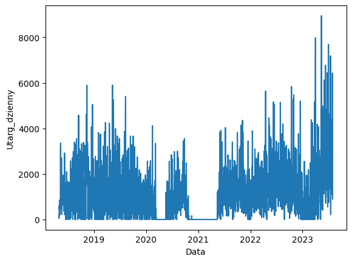

```python
sns.lineplot(x="Data",y='Utarg_dzienny',
             data=utarg_dzienny)
```

```python
# usunięcie brakującyh dat i przesunięcie czasu w 12h w tył - kolumnna 'Przesunięta_data'
mod = bills_df.loc[(bills_df != 0).any(axis=1)]
mod['Przesunięta_data']=mod['Data']-np.timedelta64(12,'h')
```

```python
#wstawienie kolumny jako index do sortowania  - metoda resample
mod.index = pd.to_datetime(mod.index)
mod=mod.set_index(pd.DatetimeIndex(mod['Przesunięta_data']))
mod.drop(['Przesunięta_data', 'Data'], axis=1)
```

| Przesunięta_data | Cena_brutto |
| --- | --- |
| 2018-12-31 11:58:00 | 31.5 |
| 2018-12-31 11:53:00 | 36.0 |
| 2018-12-31 11:46:00 | 150.3 |
| 2018-12-31 11:36:00 | 27.0 |
| 2018-12-31 11:36:00 | 8.0 |
| ... | ... |
| 2022-12-31 12:41:00 | 13.0 |
| 2022-12-31 12:39:00 | 7.0 |
| 2022-12-31 12:35:00 | 20.0 |
| 2022-12-31 12:11:00 | 14.0 |
| 2022-12-31 12:11:00 | 48.0 |

80089 rows × 1 columns

```python
#agregacja do jednego dnia i usunięcie wierszy z zerowymi utargami
rachunki_df=mod.resample('D').Cena_brutto.sum()
rachunki_df = rachunki_df.to_frame().reset_index()
rachunki_df= rachunki_df[rachunki_df['Cena_brutto'] != 0]
rachunki_df=rachunki_df.rename(columns={'Cena_brutto':'Utarg_dzienny'})
rachunki_df
```

|  | Przesunięta_data | Utarg_dzienny |
| --- | --- | --- |
| 0 | 2018-05-01 | 181.00 |
| 1 | 2018-05-02 | 52.00 |
| 2 | 2018-05-03 | 603.35 |
| 3 | 2018-05-04 | 558.20 |
| 4 | 2018-05-05 | 763.00 |
| ... | ... | ... |
| 1913 | 2023-07-27 | 1356.73 |
| 1914 | 2023-07-28 | 868.70 |
| 1915 | 2023-07-29 | 8359.70 |
| 1916 | 2023-07-30 | 1746.80 |
| 1917 | 2023-07-31 | 374.00 |

1497 rows × 2 columns

### **Wstępna obróbka danych**

#### **Problemy - wartości zerowe**

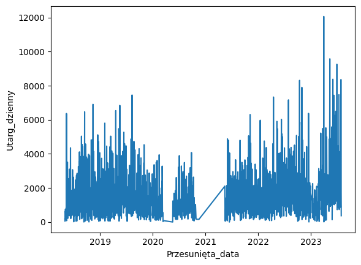

```python
#Wykres utargu po usunięciu wartości zerowych
sns.lineplot(x="Przesunięta_data",y='Utarg_dzienny',
             data=rachunki_df)
```

```python
#dodatnie kolumn z numerami tygodnia roku, miesiąca,dni tygodnia - wartość 0 odpowiada poniedziałkowi,a 6 niedzieli oraz roku
rachunki_df['nr_tygodnia'] = rachunki_df.Przesunięta_data.apply(lambda x: x.weekofyear)
rachunki_df['nr_miesiaca'] = rachunki_df.Przesunięta_data.apply(lambda x: x.month)
rachunki_df['dzien_tygodnia'] = rachunki_df.Przesunięta_data.apply(lambda x: x.dayofweek+1)
rachunki_df['rok'] = rachunki_df.Przesunięta_data.apply(lambda x: x.year)
#EDA
profile = ProfileReport(rachunki_df, title="EDA dla utargów dziennych V.2018-VII.2023")
```

### **Charakterystyka danych (EDA) - poziom deskryptywny**

```python
profile
```

[interactive chart not shown]

## **Modele refencyjne**

- **Modele naiwne**
  - średnia rocznia
  - średnia historyczna
  - powótrzenie zeszłorocznego szeregu czasowego
  - średniej dzienna z całego dyzpozycyjnego szeregu czasowego
- **Modele złożonej średnia ruchomej - średnia dla dnia tygodnia dla każdego tygodnia roku:**
  - dla ostatniego dwurocznego szeregu czasowego - postCOVID
  - dla ostatniego rocznego szeregu czasowego - postCOVID
  - dla całego dyzpozycyjnego szeregu czasowe

```python
#zbiór testowy - lipiec 2023
test_df=rachunki_df[rachunki_df['Przesunięta_data']>="2023-07-01"]
#zbiór uczący cały - do lipca 2023
baza_df=rachunki_df[rachunki_df['Przesunięta_data']<"2023-07-01"]
#zbiór uczący roczny - od lipca 2022 do lipca 2023
baza_last_df=baza_df[baza_df['Przesunięta_data']>="2022-07-01"]
#zbiór uczący dwuletni po Covidzie - od lipca 2021 do lipca 2023
baza_2rok_df=baza_df[baza_df['Przesunięta_data']>="2021-07-01"]
#zbiór uczący dwuletni po Covidzie - od lipca 2022 do lipca 2023
baza_1rok_df=baza_df[baza_df['Przesunięta_data']>="2022-07-01"]
#Powtórzenie ostatniego szergu czasowego
baza_last_df=baza_last_df.drop(['nr_tygodnia','dzien_tygodnia','rok','nr_miesiaca'], axis=1)
baza_last_df['Przesunięta_data']=baza_last_df['Przesunięta_data'].values.astype('datetime64[D]')
baza_last_df['Przesunięta_data']=baza_last_df['Przesunięta_data']+np.timedelta64(1,'Y')
baza_last_df=baza_last_df[baza_last_df['Przesunięta_data']<="2023-07-31"]
baza_last_df=baza_last_df.rename(columns={'Utarg_dzienny': "Utarg_2022"})
#Średnia ruchoma dla całego okresu
prognoza_df=baza_df.groupby(['nr_tygodnia', 'dzien_tygodnia'])['Utarg_dzienny'].mean().to_frame()
prognoza_df.reset_index()
prognoza_df=prognoza_df.rename(columns={"Utarg_dzienny":"Prognozowany_utarg_dzienny_MA"}).reset_index()
#Tablica zbiorcza
ref_df = pd.merge(test_df, prognoza_df,  how='left', on=['nr_tygodnia','dzien_tygodnia'])
ref_df = pd.merge(ref_df, baza_last_df,  how='left', on=['Przesunięta_data'])
#Średnia historyczna
ref_df['Średnia_historyczna']=baza_df['Utarg_dzienny'].mean()
#Średnia roczna
ref_df['Średnia_roczna']=baza_last_df["Utarg_2022"].mean()
#Średnia roczna
baza_df['dzień_roku'] = rachunki_df.Przesunięta_data.apply(lambda x: x.dayofyear)
baza_hist_df=baza_df.drop(['nr_tygodnia','dzien_tygodnia','rok','nr_miesiaca'], axis=1)
baza_hist_df=baza_df.groupby(['dzień_roku'])['Utarg_dzienny'].mean().to_frame()
baza_hist_df=baza_hist_df.rename(columns={"Utarg_dzienny":"Średnia_dzienna"}).reset_index()
```

```python
#Średnia ruchoma dla okresu 2-letniego
prognoza_2rok_df=baza_2rok_df.groupby(['nr_tygodnia', 'dzien_tygodnia'])['Utarg_dzienny'].mean().to_frame()
prognoza_2rok_df=prognoza_2rok_df.rename(columns={'Utarg_dzienny':"Prognozowany_utarg_dzienny_MA_2roczny"}).reset_index()
#Średnia ruchoma dla okresu 1-letniego
prognoza_1rok_df=baza_1rok_df.groupby(['nr_tygodnia', 'dzien_tygodnia'])['Utarg_dzienny'].mean().to_frame()
prognoza_1rok_df=prognoza_1rok_df.rename(columns={'Utarg_dzienny':"Prognozowany_utarg_dzienny_MA_1roczny"}).reset_index()

#Atualizacja tablicy zbiorczej
ref_df['dzień_roku'] = ref_df.Przesunięta_data.apply(lambda x: x.dayofyear)
ref_df = pd.merge(ref_df, baza_hist_df,  how='left', on=['dzień_roku'])
ref_df = pd.merge(ref_df, prognoza_2rok_df,  how='left', on=['nr_tygodnia','dzien_tygodnia'])
ref_df = pd.merge(ref_df, prognoza_1rok_df,  how='left', on=['nr_tygodnia','dzien_tygodnia'])


ref_df.head(5)
```

|  | Przesunięta_data | Utarg_dzienny | nr_tygodnia | nr_miesiaca | dzien_tygodnia | rok | Prognozowany_utarg_dzienny_MA | Utarg_2022 | Średnia_historyczna | Średnia_roczna | dzień_roku | Średnia_dzienna | Prognozowany_utarg_dzienny_MA_2roczny | Prognozowany_utarg_dzienny_MA_1roczny |
| --- | --- | --- | --- | --- | --- | --- | --- | --- | --- | --- | --- | --- | --- | --- |
| 0 | 2023-07-01 | 9258.0 | 26 | 7 | 6 | 2023 | 3066.400000 | 1659.55 | 1584.937933 | 2020.445161 | 182 | 984.0125 | 2505.70 | 4352.0 |
| 1 | 2023-07-02 | 1758.8 | 26 | 7 | 7 | 2023 | 600.340000 | 4352.00 | 1584.937933 | 2020.445161 | 183 | 1490.4300 | 955.45 | 1376.0 |
| 2 | 2023-07-03 | 731.0 | 27 | 7 | 1 | 2023 | 630.066667 | 1376.00 | 1584.937933 | 2020.445161 | 184 | 1202.1800 | 935.10 | 1225.2 |
| 3 | 2023-07-04 | 1367.4 | 27 | 7 | 2 | 2023 | 792.840000 | 1225.20 | 1584.937933 | 2020.445161 | 185 | 1561.7600 | 1019.35 | 913.8 |
| 4 | 2023-07-05 | 2715.0 | 27 | 7 | 3 | 2023 | 1970.880000 | 913.80 | 1584.937933 | 2020.445161 | 186 | 1232.6600 | 2417.05 | 2749.4 |

#### **Modele refencyjne - wyniki poziomu prognostycznego**

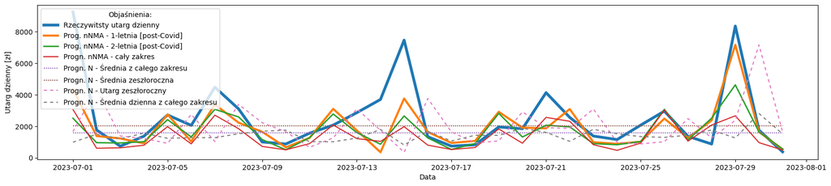

```python
#Rysowanie wykresu
plt.figure(figsize=(20,4))
sns.lineplot(x='Przesunięta_data', y='Utarg_dzienny',data=ref_df, linewidth=4,errorbar=None)
sns.lineplot(x='Przesunięta_data', y='Prognozowany_utarg_dzienny_MA_1roczny', data=ref_df, linewidth=3,errorbar=None)
sns.lineplot(x='Przesunięta_data', y='Prognozowany_utarg_dzienny_MA_2roczny', data=ref_df, linewidth=2,errorbar=None)
sns.lineplot(x='Przesunięta_data', y='Prognozowany_utarg_dzienny_MA', data=ref_df, errorbar=None)
sns.lineplot(x='Przesunięta_data', y='Średnia_historyczna', data=ref_df,dashes=(1, 1),errorbar=None)
sns.lineplot(x='Przesunięta_data', y='Średnia_roczna', data=ref_df, dashes=(1, 1),errorbar=None)
sns.lineplot(x='Przesunięta_data', y='Utarg_2022', data=ref_df, dashes=(3, 3),errorbar=None)
sns.lineplot(x='Przesunięta_data', y='Średnia_dzienna', data=ref_df, dashes=(3, 3),errorbar=None)
plt.ylabel("Utarg dzienny [zł]")
plt.xlabel("Data")
plt.legend(title='Objaśnienia:', loc='upper left', labels = ['Rzeczywitsty utarg dzienny','Prog. nNMA - 1-letnia [post-Covid]','Prog. nNMA - 2-letnia [post-Covid]','Progn. nNMA - cały zakres','Progn. N - Średnia z całego zakresu','Progn. N - Średnia zeszłoroczna' ,'Progn. N - Utarg zeszłoroczny','Progn. N - Średnia dzienna z całego zakresu'])
plt.show()
```

### **Modele refencyjne - wybór modelu**

- **MAPE** do przewidywania zamknięć i progów kosztów imprez zamkniętych; większy współczynnik błędu dla przeszacowań

[figure not shown]

- **RMSLE** do przewidywania dni testowych do obsadzeń załogi; większy współczynnik błędu dla niedoszacowań

[figure not shown]

- **MedAE** do przewidywania przepływów pieniężnych; symetryczna miara bezwględna odporna na wartości odstające

[figure not shown]

### **Model refencyjny - wybór modelu**

```python
#wyznaczenie metryk błedu dla wszystkich modeli
from sklearn.metrics import mean_absolute_percentage_error
from sklearn.metrics import mean_squared_log_error
from sklearn.metrics import median_absolute_error
columns =['Prognozowany_utarg_dzienny_MA', 'Utarg_2022', 'Średnia_historyczna','Średnia_roczna', 'Średnia_dzienna','Prognozowany_utarg_dzienny_MA_2roczny','Prognozowany_utarg_dzienny_MA_1roczny']
MAPE_score=[]
RMSLE_score=[]
MeAE_score=[]
for col in columns:
    MAPE_score.append([(mean_absolute_percentage_error(ref_df['Utarg_dzienny'], ref_df[col])),col])
    RMSLE_score.append([(mean_squared_log_error(ref_df['Utarg_dzienny'], ref_df[col])),col])
    MeAE_score.append([(median_absolute_error(ref_df['Utarg_dzienny'], ref_df[col])),col])
print('MAPE: \n',sorted(MAPE_score)[0])
print('RMSLE: \n',sorted(RMSLE_score)[0])
print('MeAE: \n',sorted(MeAE_score)[0])
```

```
MAPE:
 [0.3786949499963312, 'Prognozowany_utarg_dzienny_MA_2roczny']
RMSLE:
 [0.3220106822241443, 'Prognozowany_utarg_dzienny_MA_2roczny']
MeAE:
 [494.20000000000005, 'Prognozowany_utarg_dzienny_MA_1roczny']
```

### **Model refencyjny - poziom normatywny**

**Progi kwotowe oraz typowane dni do testów i zamknięcia**

```python
#porównianie modelu z rzeczywistymi utargami dla dni tygodnia
utarg_dzien_tyg_prog=((ref_df.groupby(['dzien_tygodnia'])['Prognozowany_utarg_dzienny_MA_2roczny']).mean())
utarg_dzien_tyg_prog.to_frame()
utarg_dzien_tyg_real=((ref_df.groupby(['dzien_tygodnia'])['Utarg_dzienny']).mean())
utarg_dzien_tyg_real.to_frame()
utarg_lipiec_2023 = pd.merge(utarg_dzien_tyg_real, utarg_dzien_tyg_prog,  how='left', on='dzien_tygodnia')
utarg_lipiec_2023['Błąd']=(utarg_lipiec_2023['Utarg_dzienny']-utarg_lipiec_2023['Prognozowany_utarg_dzienny_MA_2roczny'])
utarg_lipiec_2023['Błąd_względny']=(utarg_lipiec_2023['Błąd'])/utarg_lipiec_2023['Prognozowany_utarg_dzienny_MA_2roczny']
utarg_lipiec_2023
```

| dzien_tygodnia | Utarg_dzienny | Prognozowany_utarg_dzienny_MA_2roczny | Błąd | Błąd_względny |
| --- | --- | --- | --- | --- |
| 1 | 772.9600 | 667.16000 | 105.80000 | 0.158583 |
| 2 | 1453.3000 | 1054.90000 | 398.40000 | 0.377666 |
| 3 | 2423.1500 | 2768.94250 | -345.79250 | -0.124883 |
| 4 | 2026.7825 | 1340.15625 | 686.62625 | 0.512348 |
| 5 | 3293.7150 | 2126.94625 | 1166.76875 | 0.548565 |
| 6 | 6148.8800 | 2866.36700 | 3282.51300 | 1.145182 |
| 7 | 1442.9400 | 1179.28500 | 263.65500 | 0.223572 |

### **Model refencyjny - poziom normatywny**

**Przepływy pieniężne**

```python
#porównianie modelu przepływów pieniężnych z rzeczywistymi
ref_df['Skumulowany_Prognozowany_utarg_dzienny_MA_1roczny']=ref_df['Prognozowany_utarg_dzienny_MA_1roczny'].cumsum()
ref_df['Skumulowany_Utarg_dzienny']=ref_df['Utarg_dzienny'].cumsum()
ref_df['Błąd']=(ref_df['Skumulowany_Utarg_dzienny']-ref_df['Skumulowany_Prognozowany_utarg_dzienny_MA_1roczny'])
ref_df['Błąd_względny']=(ref_df['Błąd']/ref_df['Skumulowany_Prognozowany_utarg_dzienny_MA_1roczny'])
ref_df.filter(items=['Przesunięta_data','Skumulowany_Utarg_dzienny', 'Skumulowany_Prognozowany_utarg_dzienny_MA_1roczny','Błąd','Błąd_względny']).tail(7)
```

|  | Przesunięta_data | Skumulowany_Utarg_dzienny | Skumulowany_Prognozowany_utarg_dzienny_MA_1roczny | Błąd | Błąd_względny |
| --- | --- | --- | --- | --- | --- |
| 24 | 2023-07-25 | 62948.76 | 46056.60 | 16892.16 | 0.366770 |
| 25 | 2023-07-26 | 65905.76 | 48541.15 | 17364.61 | 0.357730 |
| 26 | 2023-07-27 | 67262.49 | 49800.85 | 17461.64 | 0.350629 |
| 27 | 2023-07-28 | 68131.19 | 52171.35 | 15959.84 | 0.305912 |
| 28 | 2023-07-29 | 76490.89 | 59337.75 | 17153.14 | 0.289076 |
| 29 | 2023-07-30 | 78237.69 | 60974.25 | 17263.44 | 0.283127 |
| 30 | 2023-07-31 | 78611.69 | 61510.25 | 17101.44 | 0.278026 |

## **Model SARIMA/SARIMAX**

### **Opis**

**S**ezonowa, **A**uto**R**egresywna, z**I**ntergorowana średnia rucho**MA** / z e**X**ternalnymi regresorami

**AR[p]** - autoregresja zakłada, że przewidywana watość szeregu czasowego, zależy od pewnej części **wartości bezpośrednio** ją poprzedzających

**I[d]** Model zakłada **stacjonarność** rokładu i jeżeli ten warunek nie jest spełniony jest on różnicowany do jego osiągnięcia

**MA[q]** - średnia ruchoma zakłada, że przewidywana watość szeregu czasowego, zależy od pewnej **ilości składników losowych** ją poprzedzających

**SA[P,D,Q]** - sezonowość zakłada, że przewidywana watość szeregu czasowego, zależy od pewnej **długości cyklu**, które ją różnicuje

**X**- **dodatkowe dane wejściowe** poza czasem w szeregu

[figure not shown]

```python
sarimaX_1rok_df=baza_1rok_df.fillna(method='ffill')
sarimaX_1rok_df['Przesunięta_data'] = pd.to_datetime(sarimaX_1rok_df['Przesunięta_data'])
```

```python
sarimaX_2rok_df=baza_2rok_df
sarimaX_2rok_df['Przesunięta_data'] = pd.to_datetime(sarimaX_2rok_df['Przesunięta_data'])
```

```python
# Automatyczna identyfikacja parametrów SARMIMAX - zbiór 2 roczny, cykliczność miesięczna
SARIMAX_2rok_msc_model = pm.auto_arima(sarimaX_2rok_df["Utarg_dzienny"],
                         exogenous=sarimaX_2rok_df[['dzien_tygodnia']],
                         max_p=7, #zakładamy max.tydzień
                         max_q=7, #zakładamy max.tydzień
                         m=12,
                         max_P=3,
                         max_Q=3,
                         max_D=3, #max. efekty interakcji sezonowej  - IIIrzędu
                         max_order=None,
                         seasonal=True,
                         d=None,
                         trace=True,
                         error_action='ignore',
                         suppress_warnings=True,
                         stepwise=True)
```

```
Performing stepwise search to minimize aic
 ARIMA(2,1,2)(1,0,1)[12] intercept   : AIC=inf, Time=2.96 sec
 ARIMA(0,1,0)(0,0,0)[12] intercept   : AIC=12190.918, Time=0.02 sec
 ARIMA(1,1,0)(1,0,0)[12] intercept   : AIC=12044.799, Time=0.29 sec
 ARIMA(0,1,1)(0,0,1)[12] intercept   : AIC=11762.040, Time=1.31 sec
 ARIMA(0,1,0)(0,0,0)[12]             : AIC=12188.924, Time=0.02 sec
 ARIMA(0,1,1)(0,0,0)[12] intercept   : AIC=11766.260, Time=0.47 sec
 ARIMA(0,1,1)(1,0,1)[12] intercept   : AIC=inf, Time=3.55 sec
 ARIMA(0,1,1)(0,0,2)[12] intercept   : AIC=11758.841, Time=4.27 sec
 ARIMA(0,1,1)(1,0,2)[12] intercept   : AIC=11761.028, Time=5.79 sec
 ARIMA(0,1,1)(0,0,3)[12] intercept   : AIC=11759.899, Time=10.23 sec
 ARIMA(0,1,1)(1,0,3)[12] intercept   : AIC=11762.585, Time=14.26 sec
 ARIMA(0,1,0)(0,0,2)[12] intercept   : AIC=12189.241, Time=0.56 sec
 ARIMA(1,1,1)(0,0,2)[12] intercept   : AIC=11760.830, Time=6.11 sec
 ARIMA(0,1,2)(0,0,2)[12] intercept   : AIC=11760.827, Time=5.36 sec
 ARIMA(1,1,0)(0,0,2)[12] intercept   : AIC=12041.187, Time=0.75 sec
 ARIMA(1,1,2)(0,0,2)[12] intercept   : AIC=11755.782, Time=4.74 sec
 ARIMA(1,1,2)(0,0,1)[12] intercept   : AIC=11759.221, Time=2.26 sec
 ARIMA(1,1,2)(1,0,2)[12] intercept   : AIC=11757.112, Time=7.52 sec
 ARIMA(1,1,2)(0,0,3)[12] intercept   : AIC=11755.900, Time=10.89 sec
 ARIMA(1,1,2)(1,0,1)[12] intercept   : AIC=11763.518, Time=2.98 sec
 ARIMA(1,1,2)(1,0,3)[12] intercept   : AIC=11754.981, Time=15.54 sec
 ARIMA(1,1,2)(2,0,3)[12] intercept   : AIC=inf, Time=18.43 sec
 ARIMA(1,1,2)(2,0,2)[12] intercept   : AIC=inf, Time=8.57 sec
 ARIMA(0,1,2)(1,0,3)[12] intercept   : AIC=11767.023, Time=14.44 sec
 ARIMA(1,1,1)(1,0,3)[12] intercept   : AIC=11782.732, Time=14.88 sec
 ARIMA(2,1,2)(1,0,3)[12] intercept   : AIC=11753.723, Time=15.34 sec
 ARIMA(2,1,2)(0,0,3)[12] intercept   : AIC=11754.488, Time=10.44 sec
 ARIMA(2,1,2)(1,0,2)[12] intercept   : AIC=11755.550, Time=7.07 sec
 ARIMA(2,1,2)(2,0,3)[12] intercept   : AIC=inf, Time=18.78 sec
 ARIMA(2,1,2)(0,0,2)[12] intercept   : AIC=11754.152, Time=5.11 sec
 ARIMA(2,1,2)(2,0,2)[12] intercept   : AIC=inf, Time=7.83 sec
 ARIMA(2,1,1)(1,0,3)[12] intercept   : AIC=11776.142, Time=15.87 sec
 ARIMA(3,1,2)(1,0,3)[12] intercept   : AIC=11753.975, Time=16.62 sec
 ARIMA(2,1,3)(1,0,3)[12] intercept   : AIC=inf, Time=19.91 sec
 ARIMA(1,1,3)(1,0,3)[12] intercept   : AIC=11761.967, Time=19.61 sec
 ARIMA(3,1,1)(1,0,3)[12] intercept   : AIC=11774.175, Time=16.71 sec
 ARIMA(3,1,3)(1,0,3)[12] intercept   : AIC=inf, Time=22.74 sec
 ARIMA(2,1,2)(1,0,3)[12]             : AIC=11753.214, Time=7.61 sec
 ARIMA(2,1,2)(0,0,3)[12]             : AIC=11753.982, Time=4.86 sec
```

[output cut: 9 more lines]

```
 ARIMA(2,1,3)(0,0,2)[12]             : AIC=11737.268, Time=6.16 sec
 ARIMA(2,1,3)(0,0,1)[12]             : AIC=11748.988, Time=1.95 sec
 ARIMA(2,1,3)(1,0,2)[12]             : AIC=11739.187, Time=9.01 sec
 ARIMA(2,1,3)(1,0,1)[12]             : AIC=11745.538, Time=3.41 sec
 ARIMA(1,1,3)(0,0,2)[12]             : AIC=11752.869, Time=4.39 sec
 ARIMA(3,1,3)(0,0,2)[12]             : AIC=11738.989, Time=7.23 sec
 ARIMA(2,1,4)(0,0,2)[12]             : AIC=11739.482, Time=8.34 sec
 ARIMA(1,1,2)(0,0,2)[12]             : AIC=11755.207, Time=2.02 sec
 ARIMA(1,1,4)(0,0,2)[12]             : AIC=11753.301, Time=6.92 sec
 ARIMA(3,1,2)(0,0,2)[12]             : AIC=11753.866, Time=2.41 sec
 ARIMA(3,1,4)(0,0,2)[12]             : AIC=11751.371, Time=8.01 sec
 ARIMA(2,1,3)(0,0,2)[12] intercept   : AIC=11739.439, Time=8.47 sec

Best model:  ARIMA(2,1,3)(0,0,2)[12]
Total fit time: 504.109 seconds
```

```python
# Automatyczna identyfikacja parametrów SARMIMAX - zbiór 2 roczny, cykliczność dniowa
SARIMAX_2rok_dz_model = pm.auto_arima(sarimaX_2rok_df["Utarg_dzienny"],
                         exogenous=sarimaX_2rok_df[['dzien_tygodnia']],
                         max_p=3, #zakładamy max.długi weekend
                         max_q=7, #zakładamy max.tydzień
                         m=7,
                         max_P=3,
                         max_Q=3,
                         max_D=3, #max. efekty interakcji sezonowej  - IIIrzędu
                         max_order=None,
                         seasonal=True,
                         d=None,
                         trace=True,
                         error_action='ignore',
                         suppress_warnings=True,
                         stepwise=True)
```

```
Performing stepwise search to minimize aic
 ARIMA(2,1,2)(1,0,1)[7] intercept   : AIC=inf, Time=2.88 sec
 ARIMA(0,1,0)(0,0,0)[7] intercept   : AIC=12190.918, Time=0.02 sec
 ARIMA(1,1,0)(1,0,0)[7] intercept   : AIC=11974.814, Time=0.15 sec
 ARIMA(0,1,1)(0,0,1)[7] intercept   : AIC=11714.801, Time=0.79 sec
 ARIMA(0,1,0)(0,0,0)[7]             : AIC=12188.924, Time=0.02 sec
 ARIMA(0,1,1)(0,0,0)[7] intercept   : AIC=11766.260, Time=0.36 sec
 ARIMA(0,1,1)(1,0,1)[7] intercept   : AIC=inf, Time=1.30 sec
 ARIMA(0,1,1)(0,0,2)[7] intercept   : AIC=11685.793, Time=2.50 sec
 ARIMA(0,1,1)(1,0,2)[7] intercept   : AIC=inf, Time=2.90 sec
 ARIMA(0,1,1)(0,0,3)[7] intercept   : AIC=inf, Time=3.44 sec
 ARIMA(0,1,1)(1,0,3)[7] intercept   : AIC=inf, Time=4.61 sec
 ARIMA(0,1,0)(0,0,2)[7] intercept   : AIC=12110.352, Time=0.25 sec
 ARIMA(1,1,1)(0,0,2)[7] intercept   : AIC=11694.045, Time=2.67 sec
 ARIMA(0,1,2)(0,0,2)[7] intercept   : AIC=11686.378, Time=2.99 sec
 ARIMA(1,1,0)(0,0,2)[7] intercept   : AIC=11968.131, Time=0.34 sec
 ARIMA(1,1,2)(0,0,2)[7] intercept   : AIC=11690.651, Time=3.12 sec
 ARIMA(0,1,1)(0,0,2)[7]             : AIC=11685.188, Time=1.47 sec
 ARIMA(0,1,1)(0,0,1)[7]             : AIC=11714.228, Time=0.67 sec
 ARIMA(0,1,1)(1,0,2)[7]             : AIC=11654.181, Time=2.98 sec
 ARIMA(0,1,1)(1,0,1)[7]             : AIC=11653.131, Time=0.84 sec
 ARIMA(0,1,1)(1,0,0)[7]             : AIC=11690.125, Time=0.76 sec
 ARIMA(0,1,1)(2,0,1)[7]             : AIC=11654.190, Time=1.68 sec
 ARIMA(0,1,1)(0,0,0)[7]             : AIC=11765.632, Time=0.18 sec
 ARIMA(0,1,1)(2,0,0)[7]             : AIC=inf, Time=0.99 sec
 ARIMA(0,1,1)(2,0,2)[7]             : AIC=inf, Time=3.17 sec
 ARIMA(0,1,0)(1,0,1)[7]             : AIC=12081.692, Time=0.20 sec
 ARIMA(1,1,1)(1,0,1)[7]             : AIC=11654.131, Time=1.24 sec
 ARIMA(0,1,2)(1,0,1)[7]             : AIC=11653.961, Time=2.13 sec
 ARIMA(1,1,0)(1,0,1)[7]             : AIC=11934.240, Time=0.74 sec
 ARIMA(1,1,2)(1,0,1)[7]             : AIC=11652.592, Time=2.55 sec
 ARIMA(1,1,2)(0,0,1)[7]             : AIC=11716.623, Time=0.71 sec
 ARIMA(1,1,2)(1,0,0)[7]             : AIC=11690.033, Time=1.43 sec
 ARIMA(1,1,2)(2,0,1)[7]             : AIC=11654.027, Time=3.33 sec
 ARIMA(1,1,2)(1,0,2)[7]             : AIC=11653.418, Time=3.74 sec
 ARIMA(1,1,2)(0,0,0)[7]             : AIC=11760.313, Time=0.28 sec
 ARIMA(1,1,2)(0,0,2)[7]             : AIC=11684.657, Time=2.47 sec
 ARIMA(1,1,2)(2,0,0)[7]             : AIC=11660.677, Time=2.27 sec
 ARIMA(1,1,2)(2,0,2)[7]             : AIC=11663.610, Time=3.86 sec
 ARIMA(2,1,2)(1,0,1)[7]             : AIC=11653.374, Time=2.62 sec
 ARIMA(1,1,3)(1,0,1)[7]             : AIC=11682.300, Time=1.93 sec
 ARIMA(0,1,3)(1,0,1)[7]             : AIC=inf, Time=1.55 sec
 ARIMA(2,1,1)(1,0,1)[7]             : AIC=inf, Time=1.74 sec
 ARIMA(2,1,3)(1,0,1)[7]             : AIC=11676.740, Time=2.29 sec
 ARIMA(1,1,2)(1,0,1)[7] intercept   : AIC=inf, Time=2.93 sec

Best model:  ARIMA(1,1,2)(1,0,1)[7]
Total fit time: 79.174 seconds
```

```python
# Automatyczna identyfikacja parametrów SARMIMAX - zbiór 1 roczny, cykliczność miesięczna
SARIMAX_1rok_msc_model = pm.auto_arima(sarimaX_1rok_df["Utarg_dzienny"],
                         exogenous=sarimaX_1rok_df[['dzien_tygodnia']],
                         max_p=3, #zakładamy max.długi weekend
                         max_q=7, #zakładamy max.tydzień
                         m=12,
                         max_P=3,
                         max_Q=3,
                         max_D=3, #max. efekty interakcji sezonowej  - IIIrzędu
                         max_order=None,
                         seasonal=True,
                         d=None,
                         trace=True,
                         error_action='ignore',
                         suppress_warnings=True,
                         stepwise=True)
```

```
Performing stepwise search to minimize aic
 ARIMA(2,1,2)(1,0,1)[12] intercept   : AIC=5722.927, Time=1.50 sec
 ARIMA(0,1,0)(0,0,0)[12] intercept   : AIC=5920.089, Time=0.03 sec
 ARIMA(1,1,0)(1,0,0)[12] intercept   : AIC=5860.588, Time=0.16 sec
 ARIMA(0,1,1)(0,0,1)[12] intercept   : AIC=5725.624, Time=0.87 sec
 ARIMA(0,1,0)(0,0,0)[12]             : AIC=5918.097, Time=0.01 sec
 ARIMA(2,1,2)(0,0,1)[12] intercept   : AIC=5722.382, Time=1.01 sec
 ARIMA(2,1,2)(0,0,0)[12] intercept   : AIC=5720.408, Time=0.49 sec
 ARIMA(2,1,2)(1,0,0)[12] intercept   : AIC=5722.390, Time=1.32 sec
 ARIMA(1,1,2)(0,0,0)[12] intercept   : AIC=5719.457, Time=0.39 sec
 ARIMA(1,1,2)(1,0,0)[12] intercept   : AIC=5721.443, Time=0.92 sec
 ARIMA(1,1,2)(0,0,1)[12] intercept   : AIC=5721.437, Time=0.84 sec
 ARIMA(1,1,2)(1,0,1)[12] intercept   : AIC=5722.219, Time=1.17 sec
 ARIMA(0,1,2)(0,0,0)[12] intercept   : AIC=5725.572, Time=0.37 sec
 ARIMA(1,1,1)(0,0,0)[12] intercept   : AIC=5725.690, Time=0.44 sec
 ARIMA(1,1,3)(0,0,0)[12] intercept   : AIC=5720.067, Time=0.89 sec
 ARIMA(0,1,1)(0,0,0)[12] intercept   : AIC=5724.010, Time=0.24 sec
 ARIMA(0,1,3)(0,0,0)[12] intercept   : AIC=5720.347, Time=0.77 sec
 ARIMA(2,1,1)(0,0,0)[12] intercept   : AIC=5721.929, Time=0.55 sec
 ARIMA(2,1,3)(0,0,0)[12] intercept   : AIC=inf, Time=1.13 sec
 ARIMA(1,1,2)(0,0,0)[12]             : AIC=5718.280, Time=0.17 sec
 ARIMA(1,1,2)(1,0,0)[12]             : AIC=5720.266, Time=0.43 sec
 ARIMA(1,1,2)(0,0,1)[12]             : AIC=5720.259, Time=0.38 sec
 ARIMA(1,1,2)(1,0,1)[12]             : AIC=inf, Time=0.76 sec
 ARIMA(0,1,2)(0,0,0)[12]             : AIC=5724.397, Time=0.21 sec
 ARIMA(1,1,1)(0,0,0)[12]             : AIC=5724.512, Time=0.22 sec
 ARIMA(2,1,2)(0,0,0)[12]             : AIC=5719.250, Time=0.21 sec
 ARIMA(1,1,3)(0,0,0)[12]             : AIC=5722.086, Time=0.25 sec
 ARIMA(0,1,1)(0,0,0)[12]             : AIC=5722.823, Time=0.13 sec
 ARIMA(0,1,3)(0,0,0)[12]             : AIC=5719.083, Time=0.28 sec
 ARIMA(2,1,1)(0,0,0)[12]             : AIC=5720.711, Time=0.26 sec
 ARIMA(2,1,3)(0,0,0)[12]             : AIC=5717.347, Time=0.64 sec
 ARIMA(2,1,3)(1,0,0)[12]             : AIC=5719.281, Time=1.55 sec
 ARIMA(2,1,3)(0,0,1)[12]             : AIC=5722.498, Time=0.87 sec
 ARIMA(2,1,3)(1,0,1)[12]             : AIC=inf, Time=2.02 sec
 ARIMA(3,1,3)(0,0,0)[12]             : AIC=5718.484, Time=0.79 sec
 ARIMA(2,1,4)(0,0,0)[12]             : AIC=5718.772, Time=0.83 sec
 ARIMA(1,1,4)(0,0,0)[12]             : AIC=5719.211, Time=0.75 sec
 ARIMA(3,1,2)(0,0,0)[12]             : AIC=5720.188, Time=0.35 sec
 ARIMA(3,1,4)(0,0,0)[12]             : AIC=inf, Time=0.78 sec

Best model:  ARIMA(2,1,3)(0,0,0)[12]
Total fit time: 25.063 seconds
```

```python
# Automatyczna identyfikacja parametrów SARMIMAX - zbiór 1 roczny, cykliczność dniowa
SARIMAX_1rok_dz_model = pm.auto_arima(sarimaX_1rok_df["Utarg_dzienny"],
                         exogenous=sarimaX_1rok_df[['dzien_tygodnia']],
                         max_q=7, #zakładamy max.tydzień
                         m=7,
                         max_D=2, #max. efekty interakcji sezonowej  - IIIrzędu
                         max_order=None,
                         seasonal=True,
                         d=None,
                         trace=True,
                         error_action='ignore',
                         suppress_warnings=True,
                         stepwise=True)
```

```
Performing stepwise search to minimize aic
 ARIMA(2,1,2)(1,0,1)[7] intercept   : AIC=5680.778, Time=1.52 sec
 ARIMA(0,1,0)(0,0,0)[7] intercept   : AIC=5920.089, Time=0.02 sec
 ARIMA(1,1,0)(1,0,0)[7] intercept   : AIC=5824.824, Time=0.31 sec
 ARIMA(0,1,1)(0,0,1)[7] intercept   : AIC=5702.058, Time=0.58 sec
 ARIMA(0,1,0)(0,0,0)[7]             : AIC=5918.097, Time=0.01 sec
 ARIMA(2,1,2)(0,0,1)[7] intercept   : AIC=5701.878, Time=0.90 sec
 ARIMA(2,1,2)(1,0,0)[7] intercept   : AIC=5692.260, Time=0.87 sec
 ARIMA(2,1,2)(2,0,1)[7] intercept   : AIC=5683.145, Time=2.31 sec
 ARIMA(2,1,2)(1,0,2)[7] intercept   : AIC=5684.521, Time=2.09 sec
 ARIMA(2,1,2)(0,0,0)[7] intercept   : AIC=5720.408, Time=0.46 sec
 ARIMA(2,1,2)(0,0,2)[7] intercept   : AIC=5689.946, Time=1.62 sec
 ARIMA(2,1,2)(2,0,0)[7] intercept   : AIC=5681.753, Time=1.78 sec
 ARIMA(2,1,2)(2,0,2)[7] intercept   : AIC=5683.945, Time=2.34 sec
 ARIMA(1,1,2)(1,0,1)[7] intercept   : AIC=inf, Time=1.34 sec
 ARIMA(2,1,1)(1,0,1)[7] intercept   : AIC=5686.927, Time=1.09 sec
 ARIMA(3,1,2)(1,0,1)[7] intercept   : AIC=inf, Time=1.90 sec
 ARIMA(2,1,3)(1,0,1)[7] intercept   : AIC=inf, Time=1.48 sec
 ARIMA(1,1,1)(1,0,1)[7] intercept   : AIC=inf, Time=1.11 sec
 ARIMA(1,1,3)(1,0,1)[7] intercept   : AIC=inf, Time=1.57 sec
 ARIMA(3,1,1)(1,0,1)[7] intercept   : AIC=5701.329, Time=1.52 sec
 ARIMA(3,1,3)(1,0,1)[7] intercept   : AIC=5693.225, Time=1.58 sec
 ARIMA(2,1,2)(1,0,1)[7]             : AIC=5677.311, Time=1.22 sec
 ARIMA(2,1,2)(0,0,1)[7]             : AIC=5700.666, Time=0.42 sec
 ARIMA(2,1,2)(1,0,0)[7]             : AIC=5690.189, Time=0.86 sec
 ARIMA(2,1,2)(2,0,1)[7]             : AIC=5680.762, Time=1.00 sec
 ARIMA(2,1,2)(1,0,2)[7]             : AIC=5679.088, Time=1.84 sec
 ARIMA(2,1,2)(0,0,0)[7]             : AIC=5719.250, Time=0.20 sec
 ARIMA(2,1,2)(0,0,2)[7]             : AIC=5688.739, Time=0.79 sec
 ARIMA(2,1,2)(2,0,0)[7]             : AIC=5680.552, Time=0.75 sec
 ARIMA(2,1,2)(2,0,2)[7]             : AIC=5682.702, Time=2.13 sec
 ARIMA(1,1,2)(1,0,1)[7]             : AIC=5676.686, Time=1.05 sec
 ARIMA(1,1,2)(0,0,1)[7]             : AIC=5700.125, Time=0.38 sec
 ARIMA(1,1,2)(1,0,0)[7]             : AIC=5690.881, Time=0.32 sec
 ARIMA(1,1,2)(2,0,1)[7]             : AIC=5677.891, Time=1.43 sec
 ARIMA(1,1,2)(1,0,2)[7]             : AIC=5677.876, Time=1.78 sec
 ARIMA(1,1,2)(0,0,0)[7]             : AIC=5718.280, Time=0.16 sec
 ARIMA(1,1,2)(0,0,2)[7]             : AIC=5686.208, Time=1.19 sec
 ARIMA(1,1,2)(2,0,0)[7]             : AIC=5681.136, Time=0.53 sec
 ARIMA(1,1,2)(2,0,2)[7]             : AIC=5682.470, Time=1.97 sec
 ARIMA(0,1,2)(1,0,1)[7]             : AIC=5679.848, Time=0.66 sec
 ARIMA(1,1,1)(1,0,1)[7]             : AIC=5680.118, Time=0.63 sec
 ARIMA(1,1,3)(1,0,1)[7]             : AIC=5677.256, Time=1.19 sec
 ARIMA(0,1,1)(1,0,1)[7]             : AIC=inf, Time=0.46 sec
 ARIMA(0,1,3)(1,0,1)[7]             : AIC=5677.023, Time=0.93 sec
 ARIMA(2,1,1)(1,0,1)[7]             : AIC=5678.435, Time=1.12 sec
 ARIMA(2,1,3)(1,0,1)[7]             : AIC=5689.838, Time=1.44 sec

Best model:  ARIMA(1,1,2)(1,0,1)[7]
Total fit time: 50.943 seconds
```

```python
#Porównanie wyników modelów
#dane z dwóch lat
display(SARIMAX_2rok_msc_model.summary())
display(SARIMAX_2rok_dz_model.summary())
#dane z ostatniego roku
display(SARIMAX_1rok_msc_model.summary())
display(SARIMAX_1rok_dz_model.summary())
```

SARIMAX Results

| Dep. Variable: | y | No. Observations: | 676 |
| --- | --- | --- | --- |
| Model: | SARIMAX(2, 1, 3)x(0, 0, [1, 2], 12) | Log Likelihood | -5860.634 |
| Date: | Wed, 16 Aug 2023 | AIC | 11737.268 |
| Time: | 06:49:08 | BIC | 11773.386 |
| Sample: | 0 | HQIC | 11751.253 |
|  | - 676 |  |  |
| Covariance Type: | opg |  |  |

|  | coef | std err | z | P>\|z\| | [0.025 | 0.975] |
| --- | --- | --- | --- | --- | --- | --- |
| ar.L1 | -0.4976 | 0.027 | -18.537 | 0.000 | -0.550 | -0.445 |
| ar.L2 | -0.9661 | 0.025 | -38.449 | 0.000 | -1.015 | -0.917 |
| ma.L1 | -0.4508 | 0.043 | -10.407 | 0.000 | -0.536 | -0.366 |
| ma.L2 | 0.4191 | 0.054 | 7.787 | 0.000 | 0.314 | 0.525 |
| ma.L3 | -0.8549 | 0.039 | -21.781 | 0.000 | -0.932 | -0.778 |
| ma.S.L12 | -0.0006 | 0.049 | -0.011 | 0.991 | -0.096 | 0.095 |
| ma.S.L24 | -0.1556 | 0.046 | -3.376 | 0.001 | -0.246 | -0.065 |
| sigma2 | 2.366e+06 | 8.03e+04 | 29.480 | 0.000 | 2.21e+06 | 2.52e+06 |

| Ljung-Box (L1) (Q): | 0.15 | Jarque-Bera (JB): | 1602.55 |
| --- | --- | --- | --- |
| Prob(Q): | 0.70 | Prob(JB): | 0.00 |
| Heteroskedasticity (H): | 2.81 | Skew: | 1.87 |
| Prob(H) (two-sided): | 0.00 | Kurtosis: | 9.56 |

Warnings:  
[1] Covariance matrix calculated using the outer product of gradients (complex-step).

SARIMAX Results

| Dep. Variable: | y | No. Observations: | 676 |
| --- | --- | --- | --- |
| Model: | SARIMAX(1, 1, 2)x(1, 0, [1], 7) | Log Likelihood | -5820.296 |
| Date: | Wed, 16 Aug 2023 | AIC | 11652.592 |
| Time: | 06:49:08 | BIC | 11679.680 |
| Sample: | 0 | HQIC | 11663.080 |
|  | - 676 |  |  |
| Covariance Type: | opg |  |  |

|  | coef | std err | z | P>\|z\| | [0.025 | 0.975] |
| --- | --- | --- | --- | --- | --- | --- |
| ar.L1 | -0.6168 | 0.257 | -2.402 | 0.016 | -1.120 | -0.114 |
| ma.L1 | -0.3028 | 0.242 | -1.252 | 0.211 | -0.777 | 0.171 |
| ma.L2 | -0.6749 | 0.235 | -2.872 | 0.004 | -1.136 | -0.214 |
| ar.S.L7 | 0.8335 | 0.049 | 16.895 | 0.000 | 0.737 | 0.930 |
| ma.S.L7 | -0.5775 | 0.070 | -8.258 | 0.000 | -0.715 | -0.440 |
| sigma2 | 1.777e+06 | 4.92e+04 | 36.135 | 0.000 | 1.68e+06 | 1.87e+06 |

| Ljung-Box (L1) (Q): | 0.41 | Jarque-Bera (JB): | 2143.39 |
| --- | --- | --- | --- |
| Prob(Q): | 0.52 | Prob(JB): | 0.00 |
| Heteroskedasticity (H): | 2.75 | Skew: | 1.95 |
| Prob(H) (two-sided): | 0.00 | Kurtosis: | 10.81 |

Warnings:  
[1] Covariance matrix calculated using the outer product of gradients (complex-step).

SARIMAX Results

| Dep. Variable: | y | No. Observations: | 324 |
| --- | --- | --- | --- |
| Model: | SARIMAX(2, 1, 3) | Log Likelihood | -2852.674 |
| Date: | Wed, 16 Aug 2023 | AIC | 5717.347 |
| Time: | 06:49:08 | BIC | 5740.013 |
| Sample: | 0 | HQIC | 5726.395 |
|  | - 324 |  |  |
| Covariance Type: | opg |  |  |

|  | coef | std err | z | P>\|z\| | [0.025 | 0.975] |
| --- | --- | --- | --- | --- | --- | --- |
| ar.L1 | -0.1256 | 0.244 | -0.515 | 0.606 | -0.603 | 0.352 |
| ar.L2 | 0.4448 | 0.248 | 1.793 | 0.073 | -0.041 | 0.931 |
| ma.L1 | -0.8006 | 0.224 | -3.574 | 0.000 | -1.240 | -0.362 |
| ma.L2 | -0.7611 | 0.149 | -5.122 | 0.000 | -1.052 | -0.470 |
| ma.L3 | 0.6016 | 0.216 | 2.780 | 0.005 | 0.177 | 1.026 |
| sigma2 | 2.729e+06 | 1.45e+05 | 18.885 | 0.000 | 2.45e+06 | 3.01e+06 |

| Ljung-Box (L1) (Q): | 0.05 | Jarque-Bera (JB): | 513.07 |
| --- | --- | --- | --- |
| Prob(Q): | 0.83 | Prob(JB): | 0.00 |
| Heteroskedasticity (H): | 1.98 | Skew: | 1.79 |
| Prob(H) (two-sided): | 0.00 | Kurtosis: | 8.03 |

Warnings:  
[1] Covariance matrix calculated using the outer product of gradients (complex-step).

SARIMAX Results

| Dep. Variable: | y | No. Observations: | 324 |
| --- | --- | --- | --- |
| Model: | SARIMAX(1, 1, 2)x(1, 0, [1], 7) | Log Likelihood | -2832.343 |
| Date: | Wed, 16 Aug 2023 | AIC | 5676.686 |
| Time: | 06:49:08 | BIC | 5699.352 |
| Sample: | 0 | HQIC | 5685.734 |
|  | - 324 |  |  |
| Covariance Type: | opg |  |  |

|  | coef | std err | z | P>\|z\| | [0.025 | 0.975] |
| --- | --- | --- | --- | --- | --- | --- |
| ar.L1 | -0.6530 | 0.207 | -3.159 | 0.002 | -1.058 | -0.248 |
| ma.L1 | -0.2193 | 0.190 | -1.154 | 0.249 | -0.592 | 0.153 |
| ma.L2 | -0.7462 | 0.178 | -4.185 | 0.000 | -1.096 | -0.397 |
| ar.S.L7 | 0.7872 | 0.097 | 8.136 | 0.000 | 0.598 | 0.977 |
| ma.S.L7 | -0.5218 | 0.133 | -3.914 | 0.000 | -0.783 | -0.260 |
| sigma2 | 2.399e+06 | 1.17e+05 | 20.579 | 0.000 | 2.17e+06 | 2.63e+06 |

| Ljung-Box (L1) (Q): | 0.47 | Jarque-Bera (JB): | 785.76 |
| --- | --- | --- | --- |
| Prob(Q): | 0.49 | Prob(JB): | 0.00 |
| Heteroskedasticity (H): | 2.99 | Skew: | 1.87 |
| Prob(H) (two-sided): | 0.00 | Kurtosis: | 9.67 |

Warnings:  
[1] Covariance matrix calculated using the outer product of gradients (complex-step).

## **Model SARIMA/SARIMAX**

### **Przedstawienie wyników dopasowania**

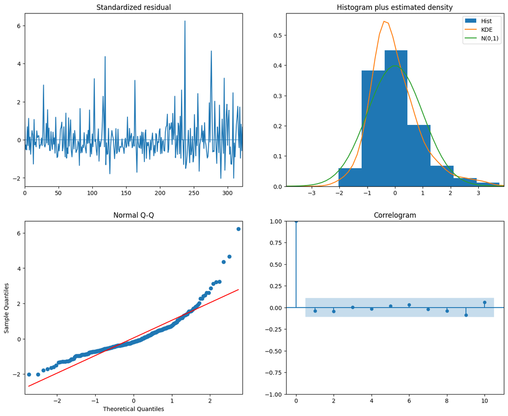

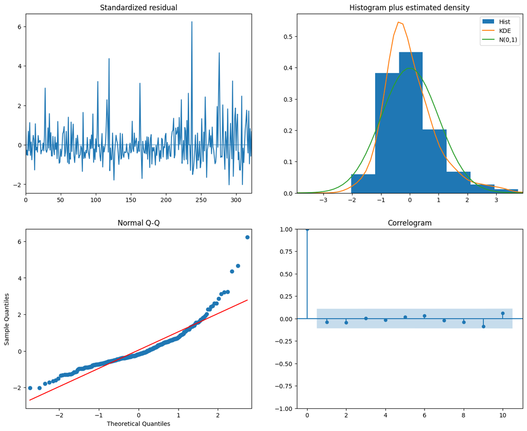

```python
SARIMAX_1rok_dz_model.plot_diagnostics(figsize=(15,12))
```

```python
display(SARIMAX_1rok_dz_model.summary())
```

SARIMAX Results

| Dep. Variable: | y | No. Observations: | 324 |
| --- | --- | --- | --- |
| Model: | SARIMAX(1, 1, 2)x(1, 0, [1], 7) | Log Likelihood | -2832.343 |
| Date: | Wed, 16 Aug 2023 | AIC | 5676.686 |
| Time: | 06:49:10 | BIC | 5699.352 |
| Sample: | 0 | HQIC | 5685.734 |
|  | - 324 |  |  |
| Covariance Type: | opg |  |  |

|  | coef | std err | z | P>\|z\| | [0.025 | 0.975] |
| --- | --- | --- | --- | --- | --- | --- |
| ar.L1 | -0.6530 | 0.207 | -3.159 | 0.002 | -1.058 | -0.248 |
| ma.L1 | -0.2193 | 0.190 | -1.154 | 0.249 | -0.592 | 0.153 |
| ma.L2 | -0.7462 | 0.178 | -4.185 | 0.000 | -1.096 | -0.397 |
| ar.S.L7 | 0.7872 | 0.097 | 8.136 | 0.000 | 0.598 | 0.977 |
| ma.S.L7 | -0.5218 | 0.133 | -3.914 | 0.000 | -0.783 | -0.260 |
| sigma2 | 2.399e+06 | 1.17e+05 | 20.579 | 0.000 | 2.17e+06 | 2.63e+06 |

| Ljung-Box (L1) (Q): | 0.47 | Jarque-Bera (JB): | 785.76 |
| --- | --- | --- | --- |
| Prob(Q): | 0.49 | Prob(JB): | 0.00 |
| Heteroskedasticity (H): | 2.99 | Skew: | 1.87 |
| Prob(H) (two-sided): | 0.00 | Kurtosis: | 9.67 |

Warnings:  
[1] Covariance matrix calculated using the outer product of gradients (complex-step).

```python
#scalenie danych treningowych i danych do prognozy i dostosowanie do analizy SARIMAX
sarimaX_test_df=test_df
sarimaX_test_df=sarimaX_test_df.set_index('Przesunięta_data').asfreq('d')
sarimaX_1rok_df=sarimaX_1rok_df.set_index(['Przesunięta_data']).asfreq('d')
sarimaX_1rok_df=sarimaX_1rok_df.fillna(method='ffill')
sarimaX_model_df=pd.concat([sarimaX_1rok_df, sarimaX_test_df])
```

```python
sarimaX_model_df
```

| Przesunięta_data | Utarg_dzienny | nr_tygodnia | nr_miesiaca | dzien_tygodnia | rok |
| --- | --- | --- | --- | --- | --- |
| 2022-07-01 | 1659.55 | 26.0 | 7.0 | 5.0 | 2022.0 |
| 2022-07-02 | 4352.00 | 26.0 | 7.0 | 6.0 | 2022.0 |
| 2022-07-03 | 1376.00 | 26.0 | 7.0 | 7.0 | 2022.0 |
| 2022-07-04 | 1225.20 | 27.0 | 7.0 | 1.0 | 2022.0 |
| 2022-07-05 | 913.80 | 27.0 | 7.0 | 2.0 | 2022.0 |
| ... | ... | ... | ... | ... | ... |
| 2023-07-27 | 1356.73 | 30.0 | 7.0 | 4.0 | 2023.0 |
| 2023-07-28 | 868.70 | 30.0 | 7.0 | 5.0 | 2023.0 |
| 2023-07-29 | 8359.70 | 30.0 | 7.0 | 6.0 | 2023.0 |
| 2023-07-30 | 1746.80 | 30.0 | 7.0 | 7.0 | 2023.0 |
| 2023-07-31 | 374.00 | 31.0 | 7.0 | 1.0 | 2023.0 |

396 rows × 5 columns

```python
#scalenie danych treningowych i danych do prognozy
import statsmodels.api as sm
model=sm.tsa.statespace.SARIMAX(sarimaX_model_df["Utarg_dzienny"],exog=sarimaX_model_df["dzien_tygodnia"],order=(1,1,2),seasonal_order=(1,0,1,7))
results=model.fit()
results.aic
```

```
6835.763645852994
```

```python
sarimax_prognoza=results.predict(start='2023-07-01',end='2023-07-31',dynamic=True)
```

```python
sarimax_prognoza_df=sarimax_prognoza.to_frame()
sarimax_prognoza_df=sarimax_prognoza.reset_index()
sarimax_prognoza_df=sarimax_prognoza_df.rename(columns={'predicted_mean': "SARIMAX_Utarg"})
sarimax_prognoza_df
```

|  | Przesunięta_data | SARIMAX_Utarg |
| --- | --- | --- |
| 0 | 2023-07-01 | 5231.983440 |
| 1 | 2023-07-02 | 2698.972809 |
| 2 | 2023-07-03 | 2323.683239 |
| 3 | 2023-07-04 | 2213.748064 |
| 4 | 2023-07-05 | 3369.195899 |
| 5 | 2023-07-06 | 2788.866894 |
| 6 | 2023-07-07 | 3733.515156 |
| 7 | 2023-07-08 | 5187.444434 |
| 8 | 2023-07-09 | 2660.963586 |
| 9 | 2023-07-10 | 2287.699367 |
| 10 | 2023-07-11 | 2180.585188 |
| 11 | 2023-07-12 | 3336.926555 |
| 12 | 2023-07-13 | 2759.925307 |
| 13 | 2023-07-14 | 3705.603257 |
| 14 | 2023-07-15 | 5159.742219 |
| 15 | 2023-07-16 | 2639.174119 |
| 16 | 2023-07-17 | 2267.346765 |
| 17 | 2023-07-18 | 2162.485152 |
| 18 | 2023-07-19 | 3319.174864 |
| 19 | 2023-07-20 | 2744.972352 |
| 20 | 2023-07-21 | 3691.173294 |
| 21 | 2023-07-22 | 5145.034735 |
| 22 | 2023-07-23 | 2629.901534 |
| 23 | 2023-07-24 | 2259.056695 |
| 24 | 2023-07-25 | 2156.008495 |
| 25 | 2023-07-26 | 3312.625954 |
| 26 | 2023-07-27 | 2740.813239 |
| 27 | 2023-07-28 | 3687.146204 |
| 28 | 2023-07-29 | 5140.354454 |
| 29 | 2023-07-30 | 2630.285808 |
| 30 | 2023-07-31 | 2260.072736 |

```python
#Atualizacja tablicy zbiorczej
ref_df = pd.merge(ref_df, sarimax_prognoza_df,  how='left', on=['Przesunięta_data'])
ref_df.head(5)
```

|  | Przesunięta_data | Utarg_dzienny | nr_tygodnia | nr_miesiaca | dzien_tygodnia | rok | Prognozowany_utarg_dzienny_MA | Utarg_2022 | Średnia_historyczna | Średnia_roczna | dzień_roku | Średnia_dzienna | Prognozowany_utarg_dzienny_MA_2roczny | Prognozowany_utarg_dzienny_MA_1roczny | Skumulowany_Prognozowany_utarg_dzienny_MA_1roczny | Skumulowany_Utarg_dzienny | Błąd | Błąd_względny | SARIMAX_Utarg |
| --- | --- | --- | --- | --- | --- | --- | --- | --- | --- | --- | --- | --- | --- | --- | --- | --- | --- | --- | --- |
| 0 | 2023-07-01 | 9258.0 | 26 | 7 | 6 | 2023 | 3066.400000 | 1659.55 | 1584.937933 | 2020.445161 | 182 | 984.0125 | 2505.70 | 4352.0 | 4352.0 | 9258.0 | 4906.0 | 1.127298 | 5231.983440 |
| 1 | 2023-07-02 | 1758.8 | 26 | 7 | 7 | 2023 | 600.340000 | 4352.00 | 1584.937933 | 2020.445161 | 183 | 1490.4300 | 955.45 | 1376.0 | 5728.0 | 11016.8 | 5288.8 | 0.923324 | 2698.972809 |
| 2 | 2023-07-03 | 731.0 | 27 | 7 | 1 | 2023 | 630.066667 | 1376.00 | 1584.937933 | 2020.445161 | 184 | 1202.1800 | 935.10 | 1225.2 | 6953.2 | 11747.8 | 4794.6 | 0.689553 | 2323.683239 |
| 3 | 2023-07-04 | 1367.4 | 27 | 7 | 2 | 2023 | 792.840000 | 1225.20 | 1584.937933 | 2020.445161 | 185 | 1561.7600 | 1019.35 | 913.8 | 7867.0 | 13115.2 | 5248.2 | 0.667116 | 2213.748064 |
| 4 | 2023-07-05 | 2715.0 | 27 | 7 | 3 | 2023 | 1970.880000 | 913.80 | 1584.937933 | 2020.445161 | 186 | 1232.6600 | 2417.05 | 2749.4 | 10616.4 | 15830.2 | 5213.8 | 0.491108 | 3369.195899 |

## **Model SARIMAX**

**Wyniki prognozy**

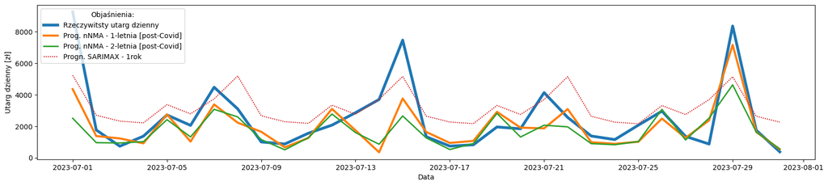

```python
#Rysowanie wykresu
plt.figure(figsize=(20,4))
sns.lineplot(x='Przesunięta_data', y='Utarg_dzienny',data=ref_df, linewidth=4,errorbar=None)
sns.lineplot(x='Przesunięta_data', y='Prognozowany_utarg_dzienny_MA_1roczny', data=ref_df, linewidth=3,errorbar=None)
sns.lineplot(x='Przesunięta_data', y='Prognozowany_utarg_dzienny_MA_2roczny', data=ref_df, linewidth=2,errorbar=None)
sns.lineplot(x='Przesunięta_data', y='SARIMAX_Utarg', data=ref_df,dashes=(1, 1), errorbar=None)
plt.ylabel("Utarg dzienny [zł]")
plt.xlabel("Data")
plt.legend(title='Objaśnienia:', loc='upper left', labels = ['Rzeczywitsty utarg dzienny','Prog. nNMA - 1-letnia [post-Covid]','Prog. nNMA - 2-letnia [post-Covid]','Progn. SARIMAX - 1rok'])
plt.show()
```

```python
columns =['Prognozowany_utarg_dzienny_MA', 'Utarg_2022', 'Średnia_historyczna','Średnia_roczna', 'Średnia_dzienna','Prognozowany_utarg_dzienny_MA_2roczny','Prognozowany_utarg_dzienny_MA_1roczny','SARIMAX_Utarg']
MAPE_score=[]
RMSLE_score=[]
MeAE_score=[]
for col in columns:
    MAPE_score.append([(mean_absolute_percentage_error(ref_df['Utarg_dzienny'], ref_df[col])),col])
    RMSLE_score.append([(mean_squared_log_error(ref_df['Utarg_dzienny'], ref_df[col])),col])
    MeAE_score.append([(median_absolute_error(ref_df['Utarg_dzienny'], ref_df[col])),col])
print('MAPE: \n',sorted(MAPE_score)[0])
print('RMSLE: \n',sorted(RMSLE_score)[0])
print('MeAE: \n',sorted(MeAE_score)[0])
```

```
MAPE:
 [0.3786949499963312, 'Prognozowany_utarg_dzienny_MA_2roczny']
RMSLE:
 [0.3220106822241443, 'Prognozowany_utarg_dzienny_MA_2roczny']
MeAE:
 [494.20000000000005, 'Prognozowany_utarg_dzienny_MA_1roczny']
```

## **Model ML**

### **Opis modelu - Random Forest**

[figure not shown]

```python
#przygotowanie danych testowych do modelu RandomForestRegressor

baza_1rok_df['dzień_roku']=baza_1rok_df['Przesunięta_data'].apply(lambda x: x.dayofyear)
test_df['dzień_roku']=test_df['Przesunięta_data'].apply(lambda x: x.dayofyear)

X_train=np.array(baza_1rok_df.drop(columns=['Utarg_dzienny','Przesunięta_data']))
y_train =np.array(baza_1rok_df.drop(columns=['nr_tygodnia','nr_miesiaca','dzien_tygodnia','rok','Przesunięta_data','dzień_roku']))
X_test=np.array(test_df.drop(columns=['Utarg_dzienny','Przesunięta_data']))
y_test =np.array(test_df.drop(columns=['nr_tygodnia','nr_miesiaca','dzien_tygodnia','rok','Przesunięta_data','dzień_roku' ]))

print(X_train.shape, X_test.shape)
print(y_train.shape, y_test.shape)
```

```
(324, 5) (31, 5)
(324, 1) (31, 1)
```

```python
#definicja modelu RandomForestRegressor
from sklearn.ensemble import RandomForestRegressor
regr = RandomForestRegressor(n_estimators=10000,bootstrap=False) # bez popróbkowania - cały zbiór; 10 000 drzew głosuje razem
regr.fit(X_train, y_train)
y_pred = regr.predict(X_test)
ML_pred_df = pd.DataFrame(y_pred, columns=['Prognoza_ML'])
ML_pred_df =ML_pred_df.set_index(test_df['Przesunięta_data'])
ML_pred_df
```

| Przesunięta_data | Prognoza_ML |
| --- | --- |
| 2023-07-01 | 4454.2000 |
| 2023-07-02 | 1387.6808 |
| 2023-07-03 | 1225.2000 |
| 2023-07-04 | 913.8000 |
| 2023-07-05 | 2413.2292 |
| 2023-07-06 | 2402.8933 |
| 2023-07-07 | 4914.1618 |
| 2023-07-08 | 2224.9000 |
| 2023-07-09 | 1646.3000 |
| 2023-07-10 | 659.9000 |
| 2023-07-11 | 1255.0000 |
| 2023-07-12 | 2415.3346 |
| 2023-07-13 | 2407.1590 |
| 2023-07-14 | 4895.9356 |
| 2023-07-15 | 3759.0000 |
| 2023-07-16 | 1635.6500 |
| 2023-07-17 | 938.6000 |
| 2023-07-18 | 1068.4000 |
| 2023-07-19 | 2414.2084 |
| 2023-07-20 | 2408.1928 |
| 2023-07-21 | 4905.0418 |
| 2023-07-22 | 3089.1000 |
| 2023-07-23 | 986.2000 |
| 2023-07-24 | 880.4000 |
| 2023-07-25 | 1016.0000 |
| 2023-07-26 | 2411.6401 |
| 2023-07-27 | 2404.2910 |
| 2023-07-28 | 4908.0826 |
| 2023-07-29 | 7166.4000 |
| 2023-07-30 | 1636.5000 |
| 2023-07-31 | 536.0000 |

```python
ref_df = pd.merge(ref_df,ML_pred_df,  how='left', on=['Przesunięta_data'])
```

```python
ref_df
```

|  | Przesunięta_data | Utarg_dzienny | nr_tygodnia | nr_miesiaca | dzien_tygodnia | rok | Prognozowany_utarg_dzienny_MA | Utarg_2022 | Średnia_historyczna | Średnia_roczna | dzień_roku | Średnia_dzienna | Prognozowany_utarg_dzienny_MA_2roczny | Prognozowany_utarg_dzienny_MA_1roczny | Skumulowany_Prognozowany_utarg_dzienny_MA_1roczny | Skumulowany_Utarg_dzienny | Błąd | Błąd_względny | SARIMAX_Utarg | Prognoza_ML |
| --- | --- | --- | --- | --- | --- | --- | --- | --- | --- | --- | --- | --- | --- | --- | --- | --- | --- | --- | --- | --- |
| 0 | 2023-07-01 | 9258.00 | 26 | 7 | 6 | 2023 | 3066.400000 | 1659.55 | 1584.937933 | 2020.445161 | 182 | 984.0125 | 2505.700 | 4352.00 | 4352.00 | 9258.00 | 4906.00 | 1.127298 | 5231.983440 | 4454.2000 |
| 1 | 2023-07-02 | 1758.80 | 26 | 7 | 7 | 2023 | 600.340000 | 4352.00 | 1584.937933 | 2020.445161 | 183 | 1490.4300 | 955.450 | 1376.00 | 5728.00 | 11016.80 | 5288.80 | 0.923324 | 2698.972809 | 1387.6808 |
| 2 | 2023-07-03 | 731.00 | 27 | 7 | 1 | 2023 | 630.066667 | 1376.00 | 1584.937933 | 2020.445161 | 184 | 1202.1800 | 935.100 | 1225.20 | 6953.20 | 11747.80 | 4794.60 | 0.689553 | 2323.683239 | 1225.2000 |
| 3 | 2023-07-04 | 1367.40 | 27 | 7 | 2 | 2023 | 792.840000 | 1225.20 | 1584.937933 | 2020.445161 | 185 | 1561.7600 | 1019.350 | 913.80 | 7867.00 | 13115.20 | 5248.20 | 0.667116 | 2213.748064 | 913.8000 |
| 4 | 2023-07-05 | 2715.00 | 27 | 7 | 3 | 2023 | 1970.880000 | 913.80 | 1584.937933 | 2020.445161 | 186 | 1232.6600 | 2417.050 | 2749.40 | 10616.40 | 15830.20 | 5213.80 | 0.491108 | 3369.195899 | 2413.2292 |
| 5 | 2023-07-06 | 2052.70 | 27 | 7 | 4 | 2023 | 878.690000 | 2749.40 | 1584.937933 | 2020.445161 | 187 | 1276.4600 | 1321.375 | 1026.75 | 11643.15 | 17882.90 | 6239.75 | 0.535916 | 2788.866894 | 2402.8933 |
| 6 | 2023-07-07 | 4475.40 | 27 | 7 | 5 | 2023 | 2700.998000 | 1026.75 | 1584.937933 | 2020.445161 | 188 | 1271.4375 | 3071.345 | 3383.70 | 15026.85 | 22358.30 | 7331.45 | 0.487890 | 3733.515156 | 4914.1618 |
| 7 | 2023-07-08 | 3101.00 | 27 | 7 | 6 | 2023 | 1845.404000 | 3383.70 | 1584.937933 | 2020.445161 | 189 | 1523.4750 | 2591.460 | 2224.90 | 17251.75 | 25459.30 | 8207.55 | 0.475752 | 5187.444434 | 2224.9000 |
| 8 | 2023-07-09 | 1000.20 | 27 | 7 | 7 | 2023 | 715.480000 | 2224.90 | 1584.937933 | 2020.445161 | 190 | 1682.7725 | 1152.500 | 1646.30 | 18898.05 | 26459.50 | 7561.45 | 0.400118 | 2660.963586 | 1646.3000 |
| 9 | 2023-07-10 | 871.20 | 28 | 7 | 1 | 2023 | 503.750000 | 1646.30 | 1584.937933 | 2020.445161 | 191 | 1750.5440 | 503.750 | 659.90 | 19557.95 | 27330.70 | 7772.75 | 0.397422 | 2287.699367 | 659.9000 |
| 10 | 2023-07-11 | 1556.10 | 28 | 7 | 2 | 2023 | 893.640000 | 659.90 | 1584.937933 | 2020.445161 | 192 | 1016.1400 | 1271.450 | 1255.00 | 20812.95 | 28886.80 | 8073.85 | 0.387924 | 2180.585188 | 1255.0000 |
| 11 | 2023-07-12 | 2068.80 | 28 | 7 | 3 | 2023 | 2079.960000 | 1255.00 | 1584.937933 | 2020.445161 | 193 | 1014.3200 | 2774.500 | 3100.30 | 23913.25 | 30955.60 | 7042.35 | 0.294496 | 3336.926555 | 2415.3346 |
| 12 | 2023-07-13 | 2860.00 | 28 | 7 | 4 | 2023 | 1213.640000 | 3100.30 | 1584.937933 | 2020.445161 | 194 | 1247.2400 | 1594.650 | 1737.70 | 25650.95 | 33815.60 | 8164.65 | 0.318298 | 2759.925307 | 2407.1590 |
| 13 | 2023-07-14 | 3699.10 | 28 | 7 | 5 | 2023 | 1037.014000 | 1737.70 | 1584.937933 | 2020.445161 | 195 | 1792.6250 | 856.735 | 346.00 | 25996.95 | 37514.70 | 11517.75 | 0.443042 | 3705.603257 | 4895.9356 |
| 14 | 2023-07-15 | 7465.40 | 28 | 7 | 6 | 2023 | 1972.180000 | 346.00 | 1584.937933 | 2020.445161 | 196 | 807.9750 | 2650.200 | 3759.00 | 29755.95 | 44980.10 | 15224.15 | 0.511634 | 5159.742219 | 3759.0000 |
| 15 | 2023-07-16 | 1331.90 | 28 | 7 | 7 | 2023 | 798.190000 | 3759.00 | 1584.937933 | 2020.445161 | 197 | 1679.3925 | 1258.075 | 1635.65 | 31391.60 | 46312.00 | 14920.40 | 0.475299 | 2639.174119 | 1635.6500 |
| 16 | 2023-07-17 | 736.60 | 29 | 7 | 1 | 2023 | 521.800000 | 1635.65 | 1584.937933 | 2020.445161 | 198 | 1061.5200 | 521.800 | 938.60 | 32330.20 | 47048.60 | 14718.40 | 0.455252 | 2267.346765 | 938.6000 |
| 17 | 2023-07-18 | 821.40 | 29 | 7 | 2 | 2023 | 648.520000 | 938.60 | 1584.937933 | 2020.445161 | 199 | 1426.5000 | 902.200 | 1068.40 | 33398.60 | 47870.00 | 14471.40 | 0.433294 | 2162.485152 | 1068.4000 |
| 18 | 2023-07-19 | 1951.80 | 29 | 7 | 3 | 2023 | 1826.798000 | 1068.40 | 1584.937933 | 2020.445161 | 200 | 1420.1800 | 2813.545 | 2912.60 | 36311.20 | 49821.80 | 13510.60 | 0.372078 | 3319.174864 | 2414.2084 |
| 19 | 2023-07-20 | 1837.70 | 29 | 7 | 4 | 2023 | 920.710000 | 2912.60 | 1584.937933 | 2020.445161 | 201 | 1868.7700 | 1315.550 | 1910.00 | 38221.20 | 51659.50 | 13438.30 | 0.351593 | 2744.972352 | 2408.1928 |
| 20 | 2023-07-21 | 4131.66 | 29 | 7 | 5 | 2023 | 2561.022000 | 1910.00 | 1584.937933 | 2020.445161 | 202 | 1611.9380 | 2063.755 | 1863.70 | 40084.90 | 55791.16 | 15706.26 | 0.391825 | 3691.173294 | 4905.0418 |
| 21 | 2023-07-22 | 2560.30 | 29 | 7 | 6 | 2023 | 2312.660000 | 1863.70 | 1584.937933 | 2020.445161 | 203 | 1041.0750 | 1959.500 | 3089.10 | 43174.00 | 58351.46 | 15177.46 | 0.351542 | 5145.034735 | 3089.1000 |
| 22 | 2023-07-23 | 1377.00 | 29 | 7 | 7 | 2023 | 825.470000 | 3089.10 | 1584.937933 | 2020.445161 | 204 | 1800.9220 | 893.900 | 986.20 | 44160.20 | 59728.46 | 15568.26 | 0.352541 | 2629.901534 | 986.2000 |
| 23 | 2023-07-24 | 1152.00 | 30 | 7 | 1 | 2023 | 469.000000 | 986.20 | 1584.937933 | 2020.445161 | 205 | 1520.2760 | 826.750 | 880.40 | 45040.60 | 60880.46 | 15839.86 | 0.351680 | 2259.056695 | 880.4000 |
| 24 | 2023-07-25 | 2068.30 | 30 | 7 | 2 | 2023 | 928.640000 | 880.40 | 1584.937933 | 2020.445161 | 206 | 1339.7300 | 1026.600 | 1016.00 | 46056.60 | 62948.76 | 16892.16 | 0.366770 | 2156.008495 | 1016.0000 |
| 25 | 2023-07-26 | 2957.00 | 30 | 7 | 3 | 2023 | 3034.990000 | 1016.00 | 1584.937933 | 2020.445161 | 207 | 1292.3600 | 3070.675 | 2484.55 | 48541.15 | 65905.76 | 17364.61 | 0.357730 | 3312.625954 | 2411.6401 |
| 26 | 2023-07-27 | 1356.73 | 30 | 7 | 4 | 2023 | 1052.336000 | 2484.55 | 1584.937933 | 2020.445161 | 208 | 1427.6300 | 1129.050 | 1259.70 | 49800.85 | 67262.49 | 17461.64 | 0.350629 | 2740.813239 | 2404.2910 |
| 27 | 2023-07-28 | 868.70 | 30 | 7 | 5 | 2023 | 2075.250000 | 1259.70 | 1584.937933 | 2020.445161 | 209 | 1759.5750 | 2515.950 | 2370.50 | 52171.35 | 68131.19 | 15959.84 | 0.305912 | 3687.146204 | 4908.0826 |
| 28 | 2023-07-29 | 8359.70 | 30 | 7 | 6 | 2023 | 2661.710000 | 2370.50 | 1584.937933 | 2020.445161 | 210 | 1254.2000 | 4624.975 | 7166.40 | 59337.75 | 76490.89 | 17153.14 | 0.289076 | 5140.354454 | 7166.4000 |
| 29 | 2023-07-30 | 1746.80 | 30 | 7 | 7 | 2023 | 959.725000 | 7166.40 | 1584.937933 | 2020.445161 | 211 | 2806.9080 | 1636.500 | 1636.50 | 60974.25 | 78237.69 | 17263.44 | 0.283127 | 2630.285808 | 1636.5000 |
| 30 | 2023-07-31 | 374.00 | 31 | 7 | 1 | 2023 | 486.466667 | 1636.50 | 1584.937933 | 2020.445161 | 212 | 1513.0500 | 548.400 | 536.00 | 61510.25 | 78611.69 | 17101.44 | 0.278026 | 2260.072736 | 536.0000 |

## **Model ML**

### **Przedstawienie wyników**

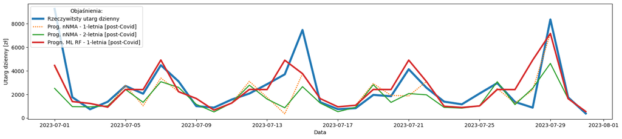

```python
#Rysowanie wykresu
plt.figure(figsize=(20,4))
sns.lineplot(x='Przesunięta_data', y='Utarg_dzienny',data=ref_df, linewidth=4,errorbar=None)
sns.lineplot(x='Przesunięta_data', y='Prognozowany_utarg_dzienny_MA_1roczny', data=ref_df, dashes=(1, 1),linewidth=2,errorbar=None)
sns.lineplot(x='Przesunięta_data', y='Prognozowany_utarg_dzienny_MA_2roczny', data=ref_df, linewidth=2,errorbar=None)
sns.lineplot(x='Przesunięta_data', y='Prognoza_ML', data=ref_df, linewidth=3,errorbar=None)
plt.ylabel("Utarg dzienny [zł]")
plt.xlabel("Data")
plt.legend(title='Objaśnienia:', loc='upper left', labels = ['Rzeczywitsty utarg dzienny','Prog. nNMA - 1-letnia [post-Covid]','Prog. nNMA - 2-letnia [post-Covid]','Progn. ML RF - 1-letnia [post-Covid]'])
plt.show()
```

```python
columns =['Prognozowany_utarg_dzienny_MA', 'Utarg_2022', 'Średnia_historyczna','Średnia_roczna', 'Średnia_dzienna','Prognozowany_utarg_dzienny_MA_2roczny','Prognozowany_utarg_dzienny_MA_1roczny','SARIMAX_Utarg','Prognoza_ML']
MAPE_score=[]
RMSLE_score=[]
MeAE_score=[]
for col in columns:
    MAPE_score.append([(mean_absolute_percentage_error(ref_df['Utarg_dzienny'], ref_df[col])),col])
    RMSLE_score.append([(mean_squared_log_error(ref_df['Utarg_dzienny'], ref_df[col])),col])
    MeAE_score.append([(median_absolute_error(ref_df['Utarg_dzienny'], ref_df[col])),col])
print('MAPE: \n',sorted(MAPE_score)[0])
print('RMSLE: \n',sorted(RMSLE_score)[0])
print('MeAE: \n',sorted(MeAE_score)[0])
```

```
MAPE:
 [0.3786949499963312, 'Prognozowany_utarg_dzienny_MA_2roczny']
RMSLE:
 [0.21652381526502323, 'Prognoza_ML']
MeAE:
 [453.6000000000597, 'Prognoza_ML']
```

#### **Możliwości dalszego rozwoju modelu:** **w oparciu o wersjonowanie danych rozszerzone o:** dane dotyczące wydarzeń zewnętrznych np. dane pogodowe, wakacje szkolne, akademickie przerwy międzysemestralne dane dotyczące wydarzeń wewnętrznych np. rodzaj wydarzeń w punkcie gastronomicznym, zmiana menu dane dotyczące środowiska rynkowego np. dane demograficzne miasta, inflacja, bezrobocie

Dziękuje za uwagę  
Proszę o pytania